# FoRt: Non-Standard Evaluation

## Wiederholung: Standard Evaluation

## R-Standard: *lexical scoping*

Finde Werte von Variablen

- basierend darauf wie Funktionen *bei ihrer Definition* ineinander verschachtelt waren (ihre *enclosures*)
- nicht basierend darauf wie ihre Aufrufe ineinander verschachtelt sind (ihre *calling environments*).

## *Lexical Scoping*: 4 Prinzipien

- **name masking**: Suchpfad entlang der *enclosures*
- **fresh start**: neues `execution environment` bei jedem Funktionsaufruf
- **dynamic look-up**: *lazy evaluation* von Funktionsargumenten
- (**functions vs. variables**)

## *Non-Standard Evaluation*

## Beispiel: `plot`

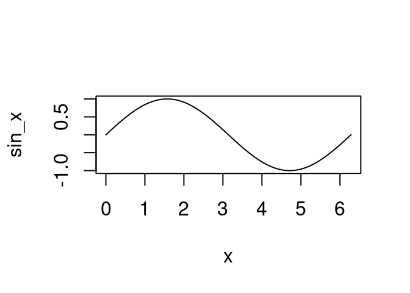

```r
x <- seq(0, 2 * pi, length = 100)
sin_x <- sin(x)
plot(x, sin_x, type = "l")
```

Woher weiss R wie die Achsen heissen?

\(\Rightarrow\) Viele Programmiersprachen können nur auf die **Werte** der Funktionsargumente zugreifen, R dagegen auch auf den **Code der sie definiert**

\(\Rightarrow\) erlaubt **non-standard evaluation** (NSE)

## Wichtige Funktionen für NSE

- `substitute()` & `deparse()`
- `eval()`
- `quote()`

## `substitute()`

- liefert für ein Funktionsargument den Code der das Funktionsargument definiert anstatt den Wert
- Rückgabewert ist also ein Ausdruck (`expression`)

```r
f <- function(x) substitute(x)

f(1:10)
```

```
## 1:10
```

```r
x <- 10
f(x)
```

```
## x
```

```r
f(x + y^2)
```

```
## x + y^2
```

- `substitute()` benutzt *lazy evaluation*-Mechanismus: Funktionsargumente sind nicht ausgewertete `expressions` (`promises`), auf diese greift `substitute()` zu **ohne** sie auszuwerten
- `substitute()` nur sinnvoll innerhalb Funktionen, Verhalten im `globalenv()` wie `quote()`

## `deparse(substitute(<arg>))`

- `deparse` wandelt `expression` in `character` um
- `deparse(substitute(<arg>))` in einem Funktionsrumpf gibt also einen String zurück, der den Code enthält der als Argument für `arg` übergeben wurde

```r
g <- function(x) deparse(substitute(x))
g(1:10)
```

```
## [1] "1:10"
```

```r
g(x)
```

```
## [1] "x"
```

```r
g(x + y^2)
```

```
## [1] "x + y^2"
```

## `deparse(substitute(<arg>))`

- nützlich v.a. für Labels, Fehlermeldungen, etc:

```r
count_rows <- function(x) message(deparse(substitute(x)), " has ", nrow(x), " rows.")
count_rows(iris)
```

```
## iris has 150 rows.
```

```r
count_rows(data.frame(1:3))
```

```
## data.frame(1:3) has 3 rows.
```

aus `base`:

```r
as.Date.default
```

```
## function (x, ...)
## {
##     if (inherits(x, "Date"))
##         x
##     else if (is.null(x))
##         .Date(numeric())
##     else if (is.logical(x) && all(is.na(x)))
##         .Date(as.numeric(x))
##     else stop(gettextf("do not know how to convert '%s' to class %s",
##         deparse1(substitute(x)), dQuote("Date")), domain = NA)
## }
## <bytecode: 0x55efb55cf020>
## <environment: namespace:base>
```

## Was kommt hier raus?

```r
f <- function(x) substitute(x)
g <- function(x) deparse(f(x))
g(1:10)
g(x)
g(x + y^2 / z + exp(a * sin(b)))
```

## NSE in subset()

Wir benutzen `subset` als Beispiel für NSE:

```r
sample_df <- data.frame(a = 1:3, b = 3:1, c = c(3, 1, 2))

subset(sample_df, a >= 2)
```

```
##   a b c
## 2 2 2 1
## 3 3 1 2
```

```r
# äquivalent:  sample_df[sample_df$a >= 2, ]

subset(sample_df, b == c)
```

```
##   a b c
## 1 1 3 3
```

```r
# äquivalent: sample_df[sample_df$b == sample_df$c, ]
```

\(\Rightarrow\) NSE mit `quote()` & `eval()`

## `quote()` & `eval()`

- `quote()` liefert einfach nur das Argument als unausgewerteten Ausdruck (`expression`) zurück.

```r
quote(1:10)
```

```
## 1:10
```

```r
quote(x)
```

```
## x
```

```r
quote(x + y^2)
```

```
## x + y^2
```

- `eval()` wertet die übergebene `expression` in einem vorgegebenen `environment` aus.

```r
arg <- "global"
env <- new.env()
env$arg <- "local"
eval(quote(arg))
```

```
## [1] "global"
```

```r
eval(quote(arg), envir = env)
```

```
## [1] "local"
```

## `quote()` & `eval()`

- `eval(quote(x))` liefert immer genau das gleiche wie `x`, `eval()` und `quote()` heben sich gegenseitig auf:

```r
eval(quote(x <- 1))
eval(quote(x))
```

```
## [1] 1
```

```r
quote(2 + 2)
```

```
## 2 + 2
```

```r
eval(quote(2 + 2))
```

```
## [1] 4
```

```r
quote(quote(2 + 2))
```

```
## quote(2 + 2)
```

```r
eval(quote(quote(2 + 2)))
```

```
## 2 + 2
```

```r
eval(eval(quote(quote(2 + 2))))
```

```
## [1] 4
```

## `eval`

- zweites Argument für `eval` kann auch Liste (also auch `data.frame`) sein – nützlich für `subset`:

```r
eval(quote(a >= 2), sample_df)
```

```
## [1] FALSE  TRUE  TRUE
```

```r
eval(quote(b == c), sample_df)
```

```
## [1]  TRUE FALSE FALSE
```

## `eval`

- Häufiger Fehler: kein `quote()` für das erste Argument:

```r
str(sample_df)
```

```
## 'data.frame':    3 obs. of  3 variables:
##  $ a: int  1 2 3
##  $ b: int  3 2 1
##  $ c: num  3 1 2
```

```r
a <- 10
eval(quote(a), sample_df)
```

```
## [1] 1 2 3
```

```r
eval(a, sample_df)
```

```
## [1] 10
```

```r
eval(quote(b), sample_df)
```

```
## [1] 3 2 1
```

```r
eval(b, sample_df)
```

```
## Error in eval(b, sample_df): object 'b' not found
```

## `subset`, die erste:

1. erhalte den Ausdruck für die Subsetbedingung mittels `substitute`
2. werte Bedingung innerhalb des `data.frame`s aus
3. benutze Ergebnis als Indexmenge:

```r
subset2 <- function(x, condition) {
  condition_call <- substitute(condition)
  use_rows <- eval(condition_call, x)
  x[use_rows, ]
}
subset2(sample_df, a >= 2)
```

```
##   a b c
## 2 2 2 1
## 3 3 1 2
```

## Kontrolle des Suchpfads: Scoping

```r
subset2
```

```
## function(x, condition) {
##   condition_call <- substitute(condition)
##   use_rows <- eval(condition_call, x)
##   x[use_rows, ]
## }
```

```r
y <- 2
x <- 2
condition <- 2
condition_call <- 2


subset2(sample_df, a == 2)
```

```
##   a b c
## 2 2 2 1
```

```r
subset2(sample_df, a == y)
```

```
##   a b c
## 2 2 2 1
```

```r
subset2(sample_df, a == x)
```

```
##     a  b  c
## 1   1  3  3
## 2   2  2  1
## 3   3  1  2
## NA NA NA NA
```

```r
subset2(sample_df, a == condition)
```

```
## [1] a b c
## <0 rows> (or 0-length row.names)
```

```r
subset2(sample_df, a == condition_call)
```

```
## [1] a b c
## <0 rows> (or 0-length row.names)
```

?!?!

## Kontrolle des Suchpfads: Scoping

- Problem: `x`, `condition`, `condition_call` nicht in `sample_df` definiert, aber innerhalb Funktion. Wenn sie nicht in `sample_df` gefunden werden werden sie als nächstes im *execution environment* der Funktionsauswertung gesucht…
- Lösung: müssen `eval()` also sagen wo es suchen soll wenn Variablen im `condition`-Argument nicht im `data.frame` sind:
- `enclos`-Argument in `eval` definiert die “Elternumgebung” (`enclosure`) von `envir` aus der heraus die Suche dann starten soll
- benutze hier die Umgebung aus der heraus `subset2` aufgerufen wurde  
  \(\rightarrow\) *dynamic scoping* mit `parent.frame()`:

```r
subset3 <- function(x, condition) {
  condition_call <- substitute(condition)
  use_rows <- eval(condition_call, envir = x, enclos = parent.frame())
  x[use_rows, ]
}
x <- 2
subset3(sample_df, a == x)
```

```
##   a b c
## 2 2 2 1
```

## Vor- und Nachteile von NSE

**+**: * unabdingbar für Plotlabels, Fehlermeldungen * unabdingbar für formelbasierte Grafik- und Modellierungsfunktionen * mächtig * flexibel * spart Tipparbeit (`subset`, `with`, `within`, etc.)

**-**: * oft schlecht aus anderen Funktionen nutzbar, gedacht für user interface (interaktive Nutzung) (besser hier: *quasi-quotation* Framework in `tidyeval`, `rlang` & Co.) * intransparenter & komplexer Code